# Used Dataset : Prosper Loan Data

# Used Columns

> Columns are divided into categorical and non categorical attributes

## Categorical Attributes

> Loan Status,Income Verifiable, Occupations, Credit Grades, Reasons For Borrowing, Prosper Score, Income Ranges

## Non Categorical Attributes

> Stated Monthly Income  
> Terms, BorrowerAPR, Debt to income ratio, Monthly Loan Payment, Employment Duration, Investors

# Credit Grade

> Found it interesting that the first three most number of loaners fall in the middle grades as shown in the graph below

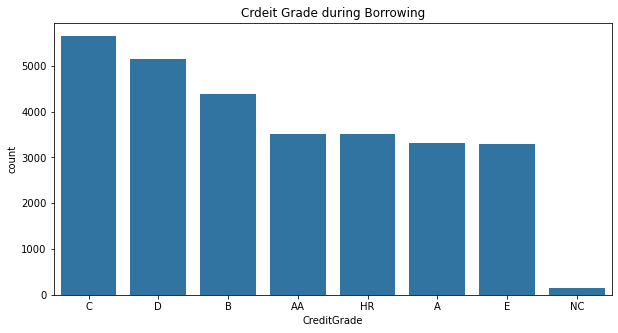

# Monthly Income

> We analyzed Monthly income that is not from the extremes " < 3 *(3rd quartile) we found that the graph tends to be right skewed and have its peak around 5000 USD  
> We then tried out the log scale and found that the graph tends to be noramlly distributed indicating that the data has low mean and high variance according to this source https://byjus.com/maths/lognormal-distribution/

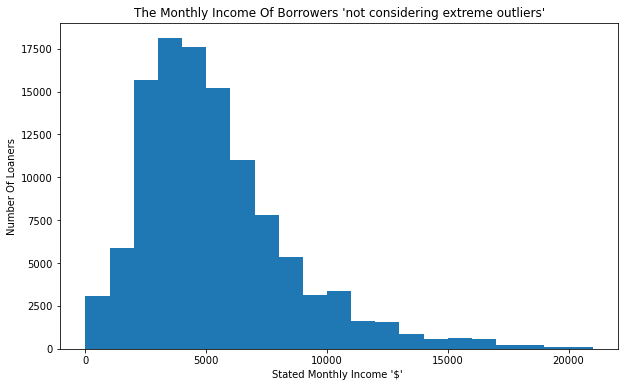

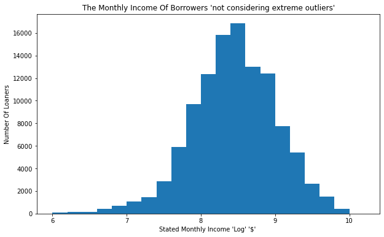

# Borrower APR

> We observed that the graph is normally distributed except for a high peak at around 0.36 - 0.38 indicating that this range is caused maybe by an external factor but couldn't figure it out

# Debt to income ratio

> Debt to income ratio is right skewed showing that most borrowers tend to have a healthy amount of debt to income ratio as the graph peaks around 0.2

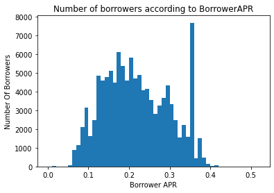

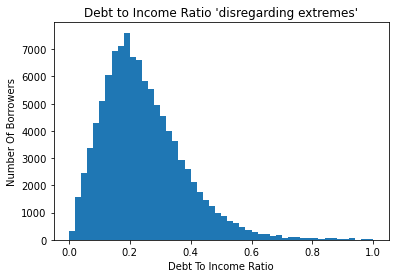

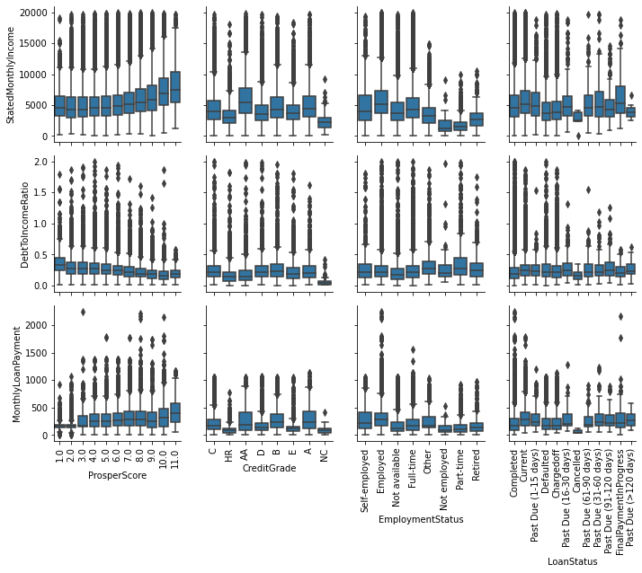

# Bivariate Data Analysis

## Prosper Score - Monthly Income Relationship

> Prosper Score and monthly income are positively correlated as the prosper score seems to increase with the increase in monthly income

## Prosper Score - Debt To Income Ratio Relationship

> Prosper score and debt to income ratio are negatively correlated as higher prosper score have lower debt to income ratio and vice versa

## Credit Grade - Monthly Income Relationship

> HR grade "High risk" has lower than normal monthly income only greater than NC

## Credit Grade - Monthly Loan Payment Relationship

> HR grade has very low monthly payment , probably to ensure their ability to pay it

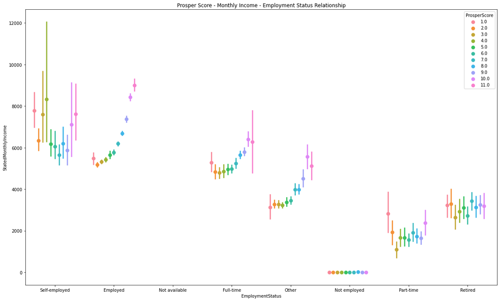

## Employment Status , Monthly Income , Prosper Score Relationship

> We observe that self employed borrowers even though having high monthly income but most of them have low prosper score "< 6 " indicating that their employment status can be considered risky causing lower scores  
> while employed and full time borrowers tend to have monthly income around the median and their prosper score is directly proportional with their monthly income  
> we also observe that retired and part time borrowers have low monthly income

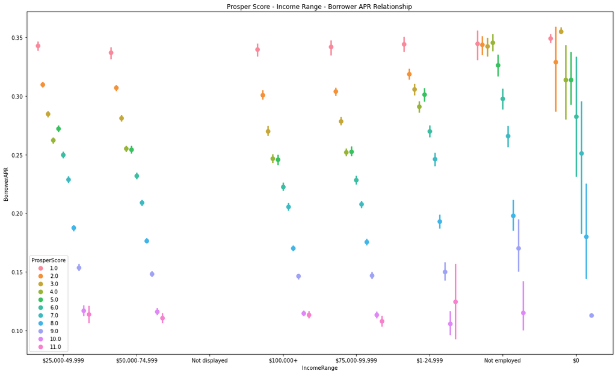

# Income Range , BorrowerAPR , Prosper Score relationship

> observed from the graph above that the relationship between BorrowerAPR and Prosper Score is inversely proportional

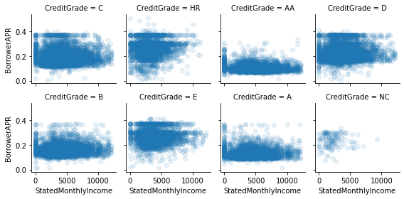

# Credit Grade , Monthly income , Borrower APR